# Cross Validation

## Cross Validation

Let us start with the question **"What is Cross Validation?"**

Cross-validation is a technique in which we train our model using the subset of the data-set and then evaluate using the complementary subset of the data-set.

In the beow illustration **k-fold Cross Validation** is used. In k-fold cross validation we split the data-set into k number of subsets(known as folds) then we perform training on the all the subsets but leave one(k-1) subset for the evaluation of the trained model. In this method, we iterate k times with a different subset reserved for testing purpose each time.

[figure not shown]

In each iteration we calculate the mean error which is called as the **Mean cross validation error**. This process is repeated for each of the models and the model which gives least Mean cross validation error is taken into consideration.

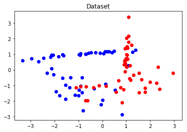

```
Kernel	C	Mean Cross Validation Error
---------------------------------------
linear 	 0.001 	 0.41015625
rbf 	 0.001 	 0.39990234375
linear 	 0.05 	 0.2301025390625
rbf 	 0.05 	 0.35009765625
linear 	 1.0 	 0.199951171875
rbf 	 1.0 	 0.159912109375
linear 	 50 	 0.199951171875
rbf 	 50 	 0.2099609375

The best Classifier has kernel= rbf   and C= 1.0
```

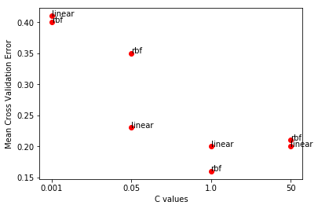

```python
from Figures import figure1
figure1.performCVandgetResult()
```